# Test a Perceptual Phenomenon

## 3. Report some descriptive statistics regarding this dataset. Include at least one measure of central tendency and at least one measure of variability

```python
# prepare data

congruentData = dataSet['Congruent']
incongruentData = dataSet['Incongruent']
```

```python
#Setup all measurement

#Central tendency
congruentData_mean = round(congruentData.mean(),2)
incongruentData_mean = round(incongruentData.mean(),2)
congruentData_median = round(congruentData.median(),2)
incongruentData_median = round(incongruentData.median(),2)

#Variability
congruentData_std = round(congruentData.std(),2)
incongruentData_std = round(incongruentData.std(),2)
```

#### For central tendency measurements:

```python
print("Congruent Data Mean:" , congruentData_mean)
print("Incongruent Data Mean:" , incongruentData_mean)
print("Congruent Data median:" , congruentData_median)
print("Incongruent Data median:" , incongruentData_median)
```

```
Congruent Data Mean: 14.05
Incongruent Data Mean: 22.02
Congruent Data median: 14.36
Incongruent Data median: 21.02
```

#### For variability measurements:

```python
print("Congruent Data std:" , congruentData_std)
print("Incongruent Data std:" , incongruentData_std)
```

```
Congruent Data std: 3.56
Incongruent Data std: 4.8
```

## 4. Provide one or two visualizations that show the distribution of the sample data. Write one or two sentences noting what you observe about the plot or plots.

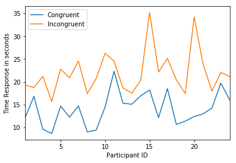

```python
dataSet.plot(x = 'Participant ID').set_ylabel('Time Response in seconds')
plt.show()
```

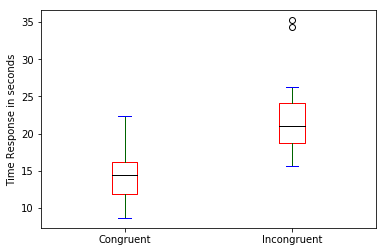

```python
dataSet.plot(x = 'Participant ID',
          kind = 'box',
          color = dict(boxes = 'Red',
                       medians = 'Black',
                       whiskers = 'DarkGreen',
                       caps = 'Blue')
         ).set_ylabel('Time Response in seconds')
plt.show()
```

> From these plots we can see that the mean of incongruent response time may not be within the t-critical from congruent response time. Also, we can also see few outliers from Incongruent (about 34 sec) that could indicate the response time is significant higher if we take more sample sizes.

## 5. Now, perform the statistical test and report your results. What is your confidence level and your critical statistic value? Do you reject the null hypothesis or fail to reject it? Come to a conclusion in terms of the experiment task. Did the results match up with your expectations?

#### What is your confidence level and your critical statistic value?

> Confidence Interval: **90%**

\begin{align}\ Df = 23 && alpha = 0.1 && t-critical= +1.714, -1.714 \end{align}

#### Do you reject the null hypothesis or fail to reject it?

```python
#standard deviation difference between congruent and incongruent

dataSet['difference'] = dataSet['Incongruent'] - dataSet['Congruent']
stdDiff = round((np.std(dataSet['difference'],ddof = 1)),3)

print('Standard deviation difference between congruent and incongruent:',stdDiff)
```

```
Standard deviation difference between congruent and incongruent: 4.865
```

```python
# Point Estimate
point_estimate = round((incongruentData_mean - congruentData_mean),2)
print('point estimate:',point_estimate)
```

```
point estimate: 7.97
```

```python
# t-statistic

t_statistic = round(point_estimate/(s/math.sqrt(24)),3) # 24 is n

print('t-statistic:',t_statistic)
```

```
t-statistic: 8.026
```

> We can see that t-statistic is greater than t-critical by a significant amount where the t-statistic is 8.026 > 1.714 which is t-critical and since this is the result **we reject the null hypothesis** which is that there is no significant difference between response time in these tests.

#### Did the results match up with your expectations?

> This result does make sense that people take longer time to process information that contradict to their existed perception toward the subject.

## References:

> - https://stats.stackexchange.com/
> - https://stackoverflow.com
> - https://www.udacity.com
> - https://github.com